# MovieLens Dataset

September 2018

## MovieLens Dataset

**MovieLens** is a web-based recommender system and virtual community that recommends movies for its users to watch, based on their film preferences using collaborative filtering of members' movie ratings and movie reviews.

The dataset contains:

- over 1.000.000 ratings
- from more than 6.000 users
- about 4.000 movies

It's divided in three datasets: Users, Movies, Ratings

## Users Dataset

| userID | gender | age | occupation | zipCode |
| --- | --- | --- | --- | --- |
| 1 | F | <18 | K-12 student | 48067 |
| 2 | M | 56+ | self-employed | 70072 |
| 3 | M | 25-34 | scientist | 55117 |
| 4 | M | 45-49 | executive/managerial | 2460 |
| 5 | M | 25-34 | writer | 55455 |
| 6 | F | 50-55 | homemaker | 55117 |
| 7 | M | 35-44 | academic/educator | 6810 |
| 8 | M | 25-34 | programmer | 11413 |
| 9 | M | 25-34 | technician/engineer | 61614 |
| 10 | F | 35-44 | academic/educator | 95370 |

## Male-Female Users

Male Proportion: 0.717

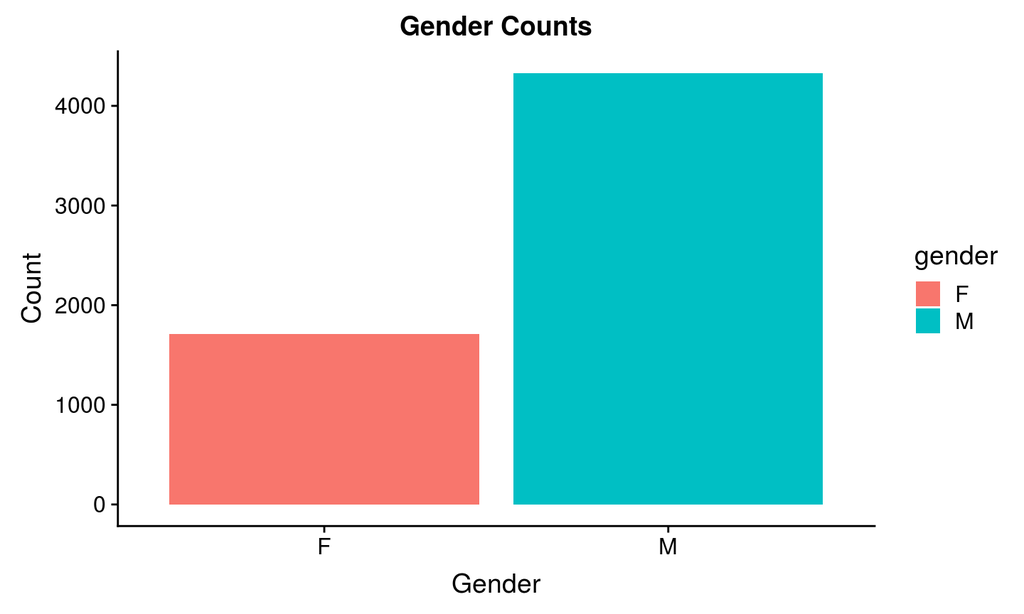

## Users' Ages

The age is divided in 7 categories:

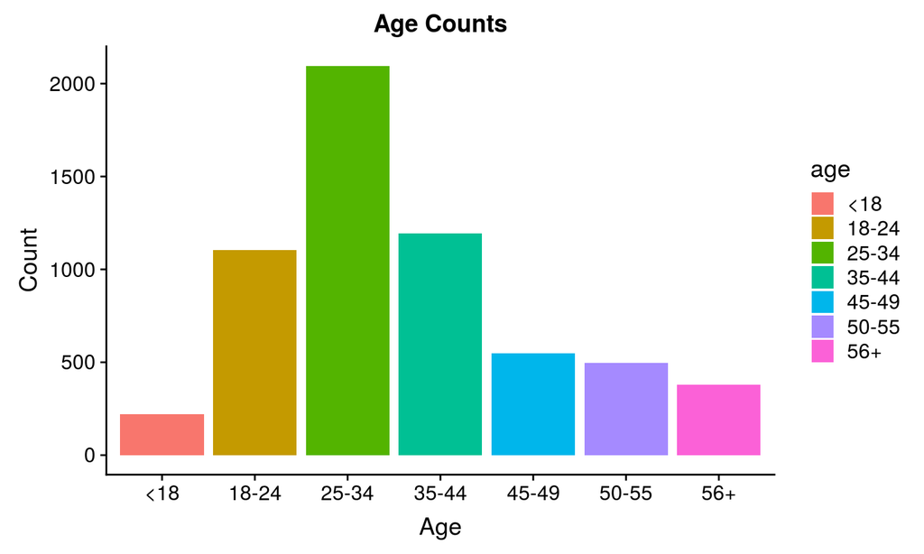

## Occupations

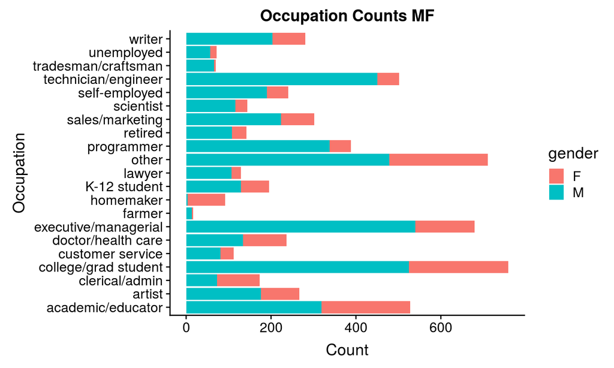

## Occupation-Gender Proportions

Female: homemaker, clerical, doctor Male: tradesman, technician, programmer

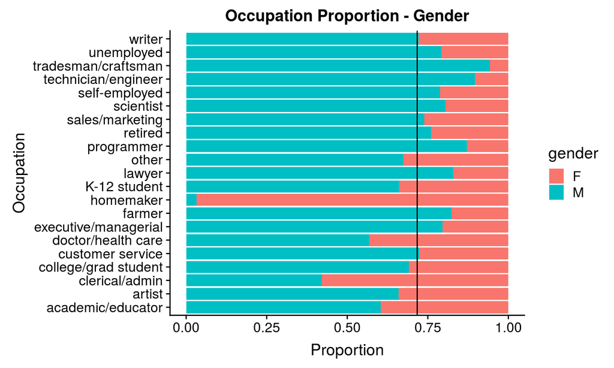

## Occupation-Age Proportions

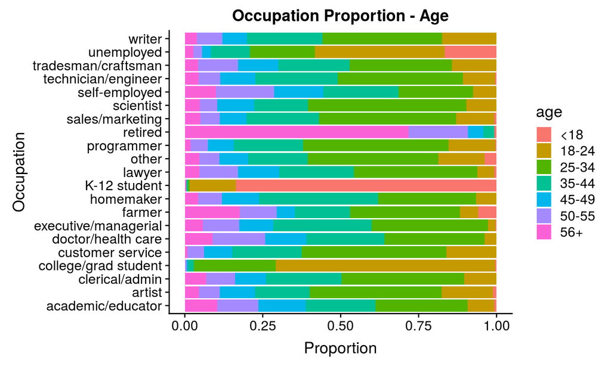

## ZipCode Dataset

The majority of users are from US

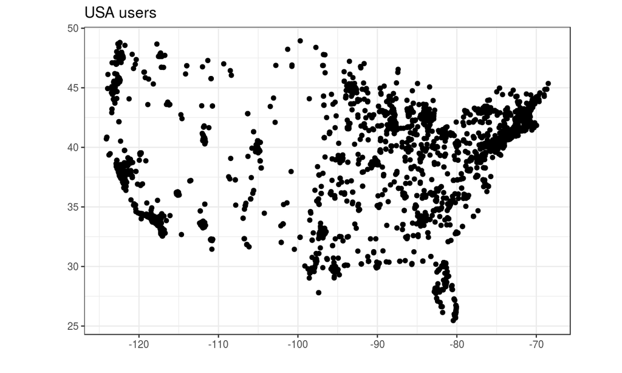

## Movies Dataset

| movieID | title | year | Action | Adventure | Animation |
| --- | --- | --- | --- | --- | --- |
| 1 | Toy Story | 1995 | 0 | 0 | 1 |
| 2 | Jumanji | 1995 | 0 | 1 | 0 |
| 3 | Grumpier Old Men | 1995 | 0 | 0 | 0 |
| 4 | Waiting to Exhale | 1995 | 0 | 0 | 0 |
| 5 | Father of the Bride Part II | 1995 | 0 | 0 | 0 |
| 6 | Heat | 1995 | 1 | 0 | 0 |
| 7 | Sabrina | 1995 | 0 | 0 | 0 |
| 8 | Tom and Huck | 1995 | 0 | 1 | 0 |
| 9 | Sudden Death | 1995 | 1 | 0 | 0 |
| 10 | GoldenEye | 1995 | 1 | 1 | 0 |

## Movies Years

More movies in the recent years

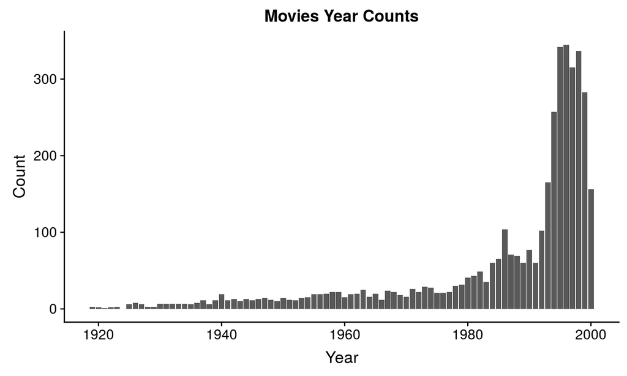

## Movies Genres

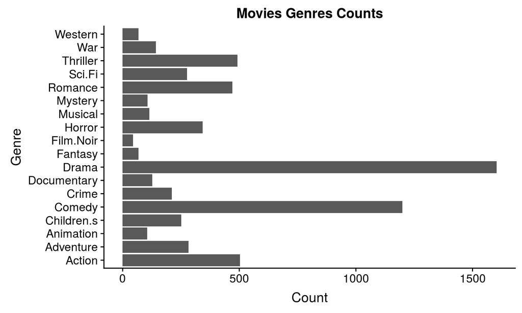

## Ratings Dataset

| userID | movieID | rating | time |
| --- | --- | --- | --- |
| 1 | 1193 | 5 | 2000-12-31 |
| 1 | 661 | 3 | 2000-12-31 |
| 1 | 914 | 3 | 2000-12-31 |
| 1 | 3408 | 4 | 2000-12-31 |
| 1 | 2355 | 5 | 2001-01-07 |
| 1 | 1197 | 3 | 2000-12-31 |
| 1 | 1287 | 5 | 2000-12-31 |
| 1 | 2804 | 5 | 2000-12-31 |
| 1 | 594 | 4 | 2000-12-31 |
| 1 | 919 | 4 | 2000-12-31 |

## Ratings

People tend to see and rate movies they like

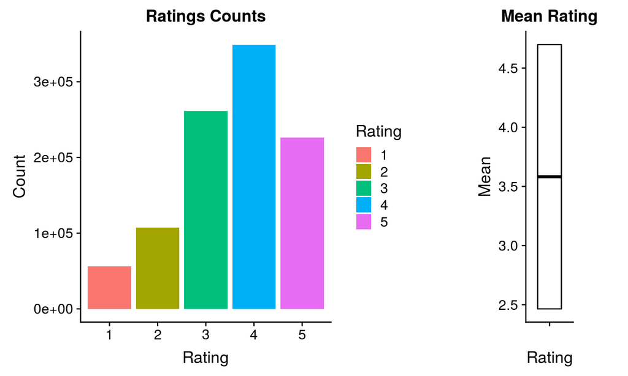

## Male-Female Ratings

Dashed line = ratings proportion  
Full line = gender proportion

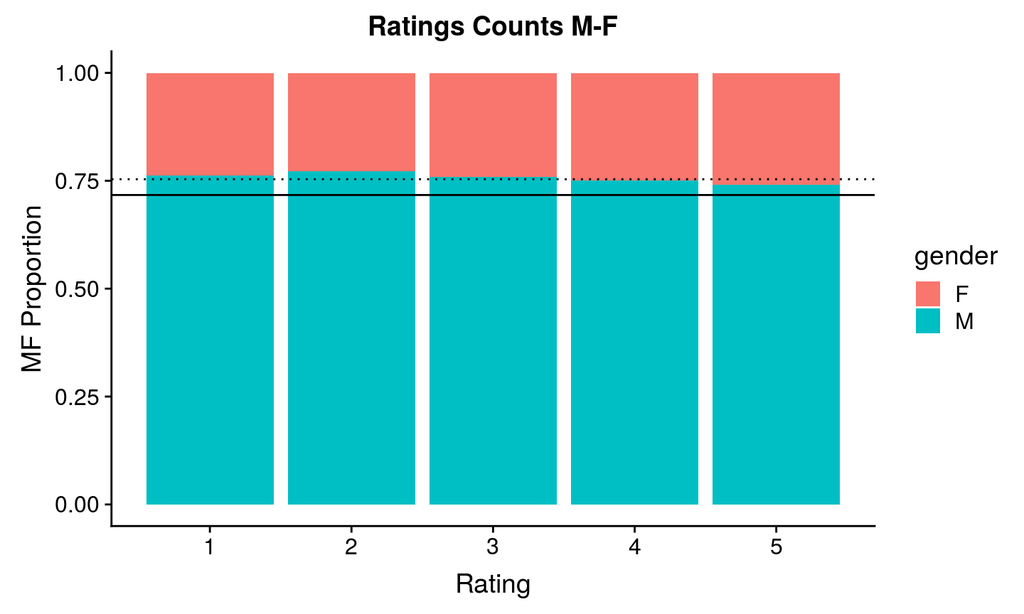

## Age Ratings

Older people's ratings are higher then younger ones…

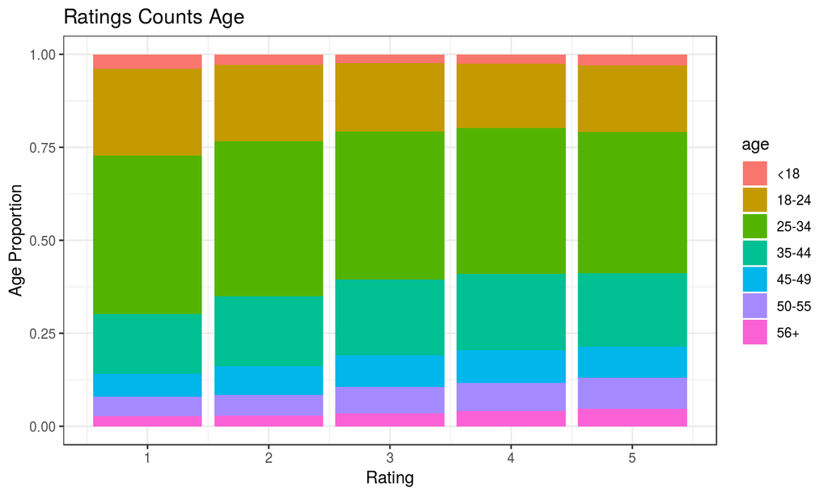

## Age - Year

The mean year of rated movies

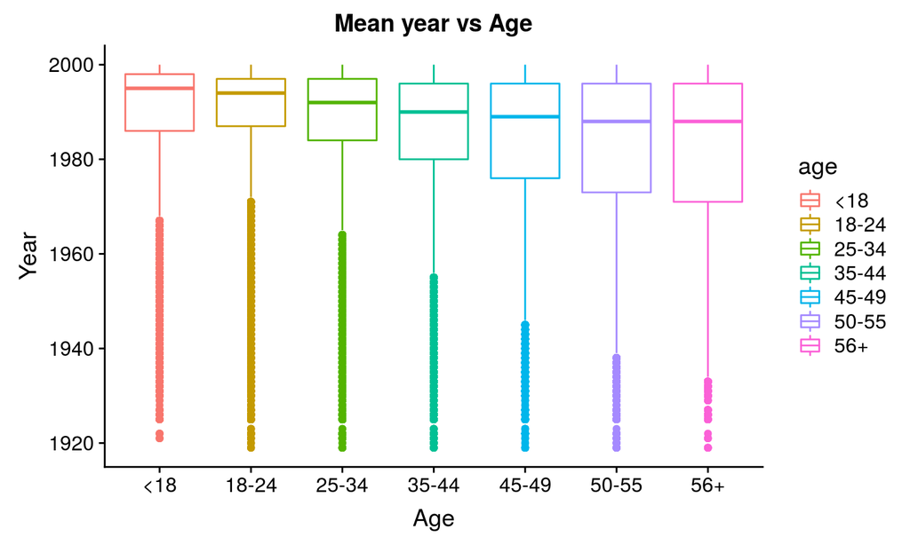

## Decade - Age

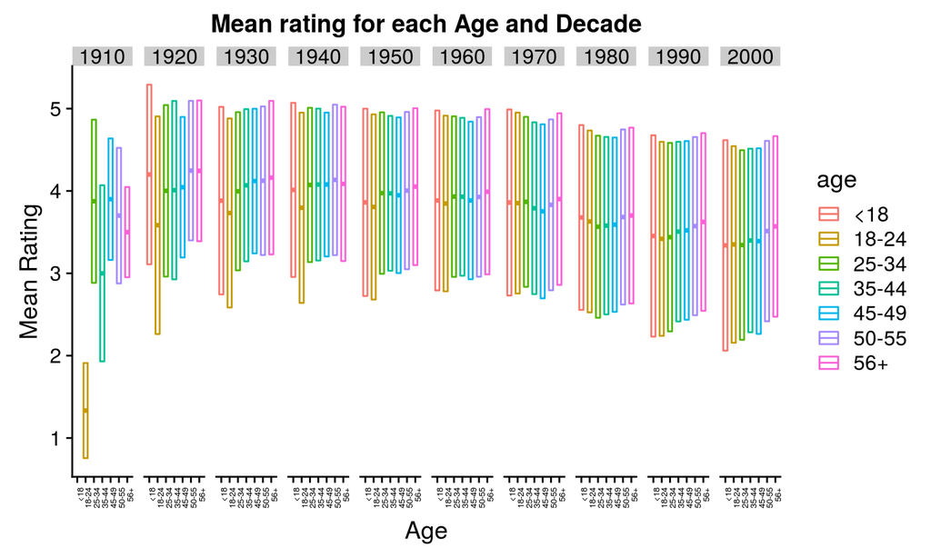

## Age - Decade

But from this plot is clear that for all ages, older movies have a higher vote

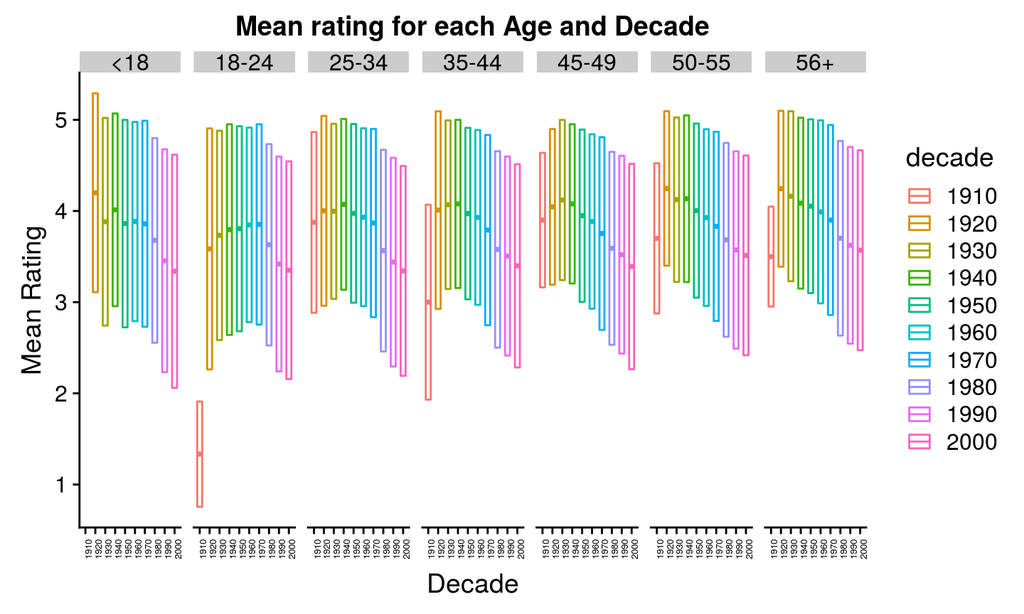

## Genre - Gender

Males prefer Westerns  
Female prefers Romance, Children's and Musicals

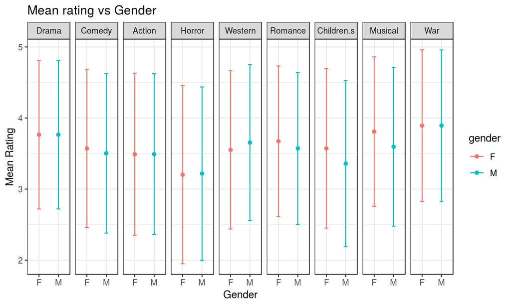

## Genre - Age

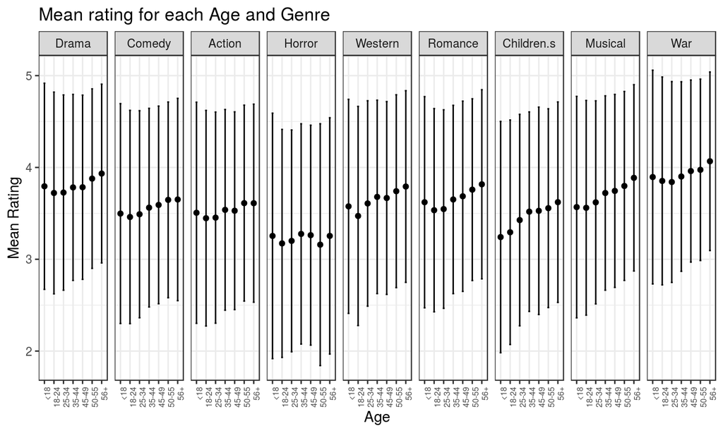

## Genre - Occupation

The occupation does not affect the genre selection

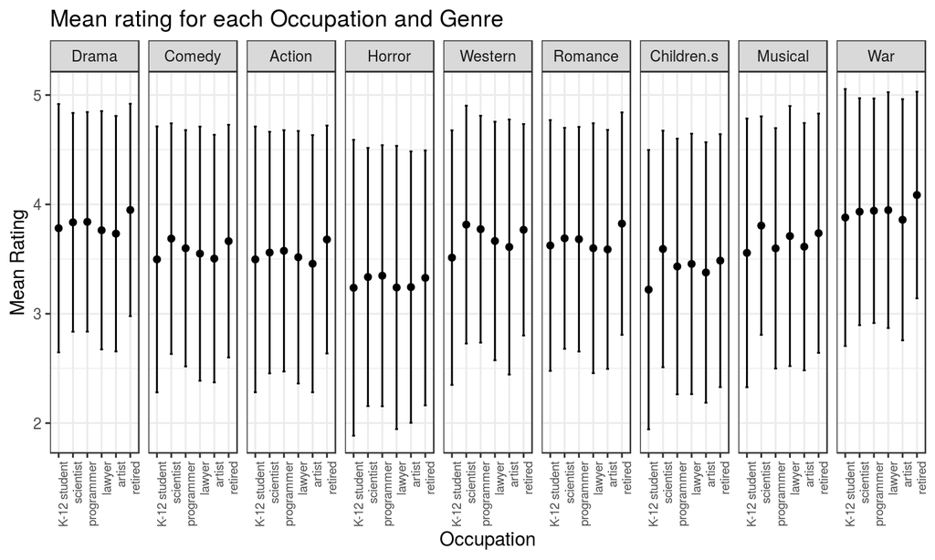

## Conclusions

It's hard to predict the taste of a user using only his/her generic data:

- Age is slightly related to the year of rated movies and older users tend to rate older movies.
- In general older movies received higher votes, while older people give higher votes.
- Gender is slightly related to the movies' genre but only for some of them (especially Musicals and Childrens' movies)
- The occupation of a user contain no information about his/her tastes.